# Part II - (San Francisco FordGo Bikeshare Analysis)

## by (Christabel Uzor)

## Investigation Overview

> The main purpose of this investigation is to enable the fordgo bikeshare business owners know where and how they should channel more of their marketing and advertisement strategies to by drawing insights from the following analysis;
> - Which gender go on longer trips?
> - What gender has longer trip durations on weekdays?
> - What days of the week have the highest number of trips?
> - Which type of users go on longer trips?
> - What hours of the day have the highest number of trips?

## Dataset Overview

> Bike sharing is a form of transportation that is easy to use, enjoyable and convenient. it involves a number of bikes parked at different locations where people can rent a bike by unlocking it with an app and returning after use to any bike station around the city. Unlocked bikes can be returned to any other station in the system, even if they were originally rented from a different station. People use bike sharing for many different reasons, such as commuting to work or school, running errands, and getting to and from appointments. There are about 183,412 records and 16 features in the bike share 2019 records dataset used for this project.

## Which gender go on longer trips?

> From the duration versus gender plot, we can see that the male gender covers more duration than the female gender and other gender types.

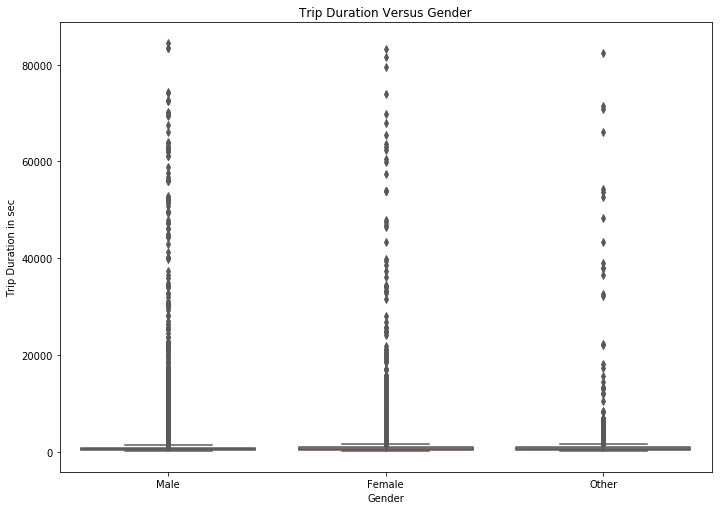

## What gender has longer trip durations on weekdays?

> The female gender seems to have longer trip durations on weekdays than the males. Even though the males cover longer durations on their trips than the females from previous analysis

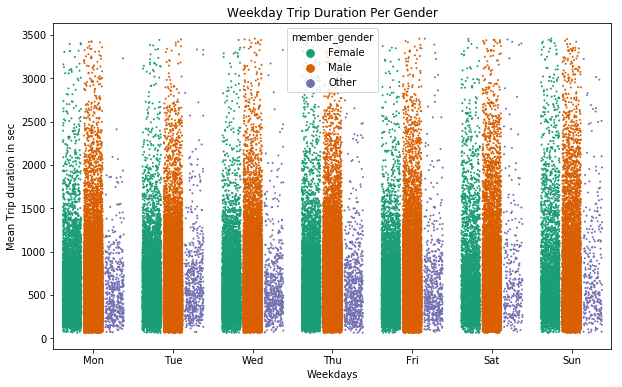

## What days of the week have the highest number of trips?

> In the chart below, it is observed that Thursday has the highest number of trips, followed by Tuesday, then wednesday. While saturday and sunday seems to have expected reduction on trips, since most people will likely be at home for weekends.

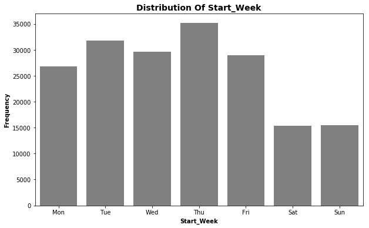

## Which type of users go on longer trips?

> From the chart below, it can be seen that subscriber users are more than the customers. I will advice that the fordgobike share business owners should channel more of their marketing and advertisement to the subscribers.

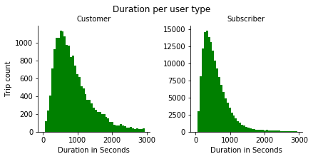

## What hours of the day have the highest number of trips?

> In the number of trips per hour chart below, it is observed that the highest trips happens to be around 8 am in the morning and 5pm (17) in the evening. This observation is very realistic, since people go to work early in the morning at about 8am and returns around 5pm in the evening. I also observed that 3am in the morning has the lowest trip to occur probably because people are sleeping at that time.

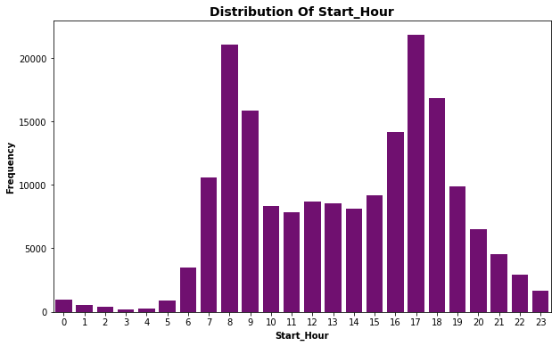